# 第四單元：資料處理與繪圖套件案例

中山大學管理學院 卓雍然

2019-03-22 17:04:38

**單元摘要：** 使用第三周作業互評的數據來練習R的

- 資料處理(dplyr)與繪圖套件
  - `dplyr`
  - `tidyr`
- 繪圖套件
  - `ggplot2`

(安裝)載入套件

```r
pacman::p_load(dplyr, tidyr, ggplot2, ggthemes)
```

### 【A】The Ascomebe Quartet

[The Ascomebe Quartet](https://en.wikipedia.org/wiki/Anscombe%27s_quartet)完全不同的數據有可能會產生完全相同的統計量，以下我們練習使用R的資料處理(`tidyr`,`dplyr`)和繪圖套件(`ggplot2`)來畫Ascomebe Quartet.

先讀進並檢視資料

```r
A = read.csv("data/anscombe.csv")
head(A)
```

```
  X x1 x2 x3 x4   y1   y2    y3   y4
1 1 10 10 10  8 8.04 9.14  7.46 6.58
2 2  8  8  8  8 6.95 8.14  6.77 5.76
3 3 13 13 13  8 7.58 8.74 12.74 7.71
4 4  9  9  9  8 8.81 8.77  7.11 8.84
5 5 11 11 11  8 8.33 9.26  7.81 8.47
6 6 14 14 14  8 9.96 8.10  8.84 7.04
```

轉換資料排列方式

```r
A = as.matrix(A)
A = cbind(
  rep(1:4, each=11), rep(1:11, 4),
  rbind(A[,c(2,6)],A[,c(3,7)],A[,c(4,8)],A[,c(5,9)])) %>%
  data.frame %>% as.tbl %>%
  setNames(c("set","id","x","y"))
head(A,12)
```

```
# A tibble: 12 x 4
     set    id     x     y
   <dbl> <dbl> <dbl> <dbl>
 1     1     1    10  8.04
 2     1     2     8  6.95
 3     1     3    13  7.58
 4     1     4     9  8.81
 5     1     5    11  8.33
 6     1     6    14  9.96
 7     1     7     6  7.24
 8     1     8     4  4.26
 9     1     9    12 10.8
10     1    10     7  4.82
11     1    11     5  5.68
12     2     1    10  9.14
```

畫出圖形

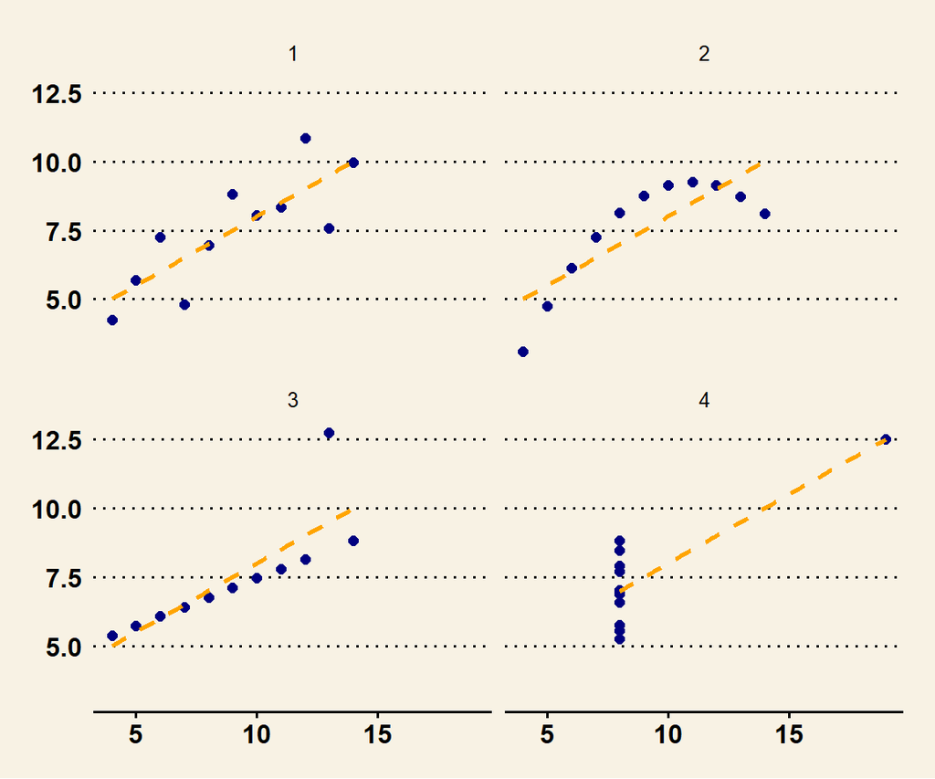

```r
ggplot(A, aes(x, y)) +
  geom_point(size=2, col='navyblue') +
  geom_smooth(method="lm", se=F, col="orange", lty=2) +
  facet_wrap(~set) +
  theme_wsj()
```

### 【B】目的導向的圖形設計

#### FIG1 - 互評進度圖

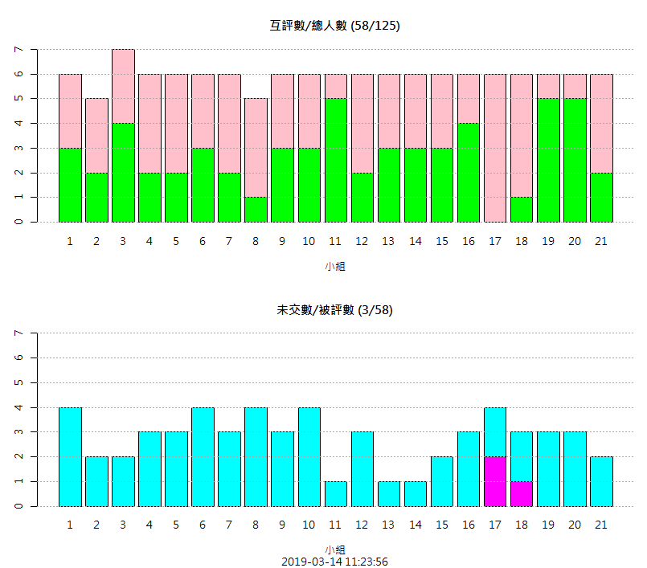

🗿 問題討論：  
■ 「互評進度圖」的目的是？  
■ 我們如何使用圖形來促成這個目的？  
■ 你覺得這做會有效嗎？ 為甚麼？

```r
#了解目前進度與促進繳交率
#使用長條圖
#蠻有效的可以警示未繳交的也能讓已繳交的組員督促
```

### 【C】匿名互評資料探索性分析

以下資料的人名和小組名稱都已經過匿名化處理：

- xID：評分者ID
- xGrade：`B`-大學部； `M`-研究所
- xTeam：評分者組別
- rTeam：被評組別

```r
load("data/X.rdata")
str(X)
```

```
'data.frame':   116 obs. of  13 variables:
 $ xID      : Factor w/ 116 levels "ID1","ID10","ID100",..: 34 99 33 105 68 111 23 50 73 39 ...
 $ xGrade   : Factor w/ 2 levels "B","M": 1 1 1 1 2 2 2 2 1 2 ...
 $ xTeam    : Factor w/ 21 levels "XT01","XT02",..: 20 15 6 17 9 1 14 12 1 6 ...
 $ rTeam    : Factor w/ 21 levels "RT01","RT02",..: 2 21 14 9 13 8 21 5 21 15 ...
 $ AS31.程式: int  6 9 8 7 8 7 10 8 6 9 ...
 $ AS31.註解: int  6 6 8 7 8 7 7 8 6 9 ...
 $ AS31.整體: int  6 8 8 7 8 6 7 8 6 8 ...
 $ AS32.程式: int  7 9 9 7 9 7 9 8 10 8 ...
 $ AS32.註解: int  7 6 9 6 8 7 7 8 6 8 ...
 $ AS32.整體: int  7 8 9 7 8 6 7 8 8 7 ...
 $ AS33.程式: int  8 9 8 7 9 7 10 7 9 9 ...
 $ AS33.註解: int  8 8 8 7 8 9 8 7 8 9 ...
 $ AS33.整體: int  8 9 8 7 8 8 8 7 8 8 ...
```

#### 各組別 評分數量 & 評分數量：

```r
rbind(table(X$xTeam), table(X$rTeam))
```

```
     XT01 XT02 XT03 XT04 XT05 XT06 XT07 XT08 XT09 XT10 XT11 XT12 XT13 XT14 XT15
[1,]    6    6    5    6    6    6    5    6    6    5    6    5    5    6    5
[2,]    5    5    5    6    5    6    5    6    5    6    5    6    6    6    5
     XT16 XT17 XT18 XT19 XT20 XT21
[1,]    4    6    6    6    5    5
[2,]    6    4    6    6    6    6
```

#### 轉換資料排列 Data Alignment

```r
X2 = gather(X, "key", "Score", 5:13) %>% separate(key, c("AS","TYPE"), sep="\\.")
X2[4:5] = lapply(X2[4:5], factor)
as.tbl(X2)
```

```
# A tibble: 1,044 x 7
   xID   xGrade xTeam rTeam AS    TYPE  Score
   <fct> <fct>  <fct> <fct> <fct> <chr> <int>
 1 ID24  B      XT20  RT02  AS31  程式      6
 2 ID83  B      XT15  RT21  AS31  程式      9
 3 ID23  B      XT06  RT14  AS31  程式      8
 4 ID89  B      XT17  RT09  AS31  程式      7
 5 ID55  M      XT09  RT13  AS31  程式      8
 6 ID94  M      XT01  RT08  AS31  程式      7
 7 ID14  M      XT14  RT21  AS31  程式     10
 8 ID39  M      XT12  RT05  AS31  程式      8
 9 ID6   B      XT01  RT21  AS31  程式      6
10 ID29  M      XT06  RT15  AS31  程式      9
# ... with 1,034 more rows
```

#### 所有評分的分布

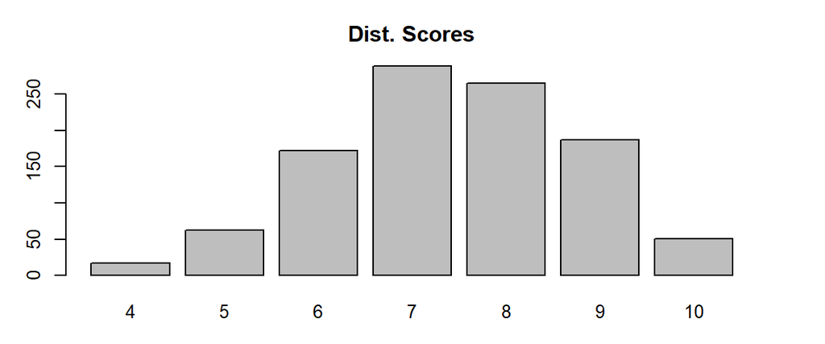

```r
par(cex=0.8, mar=c(3,3,3,3))
table(X2$Score) %>% barplot(main="Dist. Scores")
```

#### 評分的分布 3作業 x 3評分標準

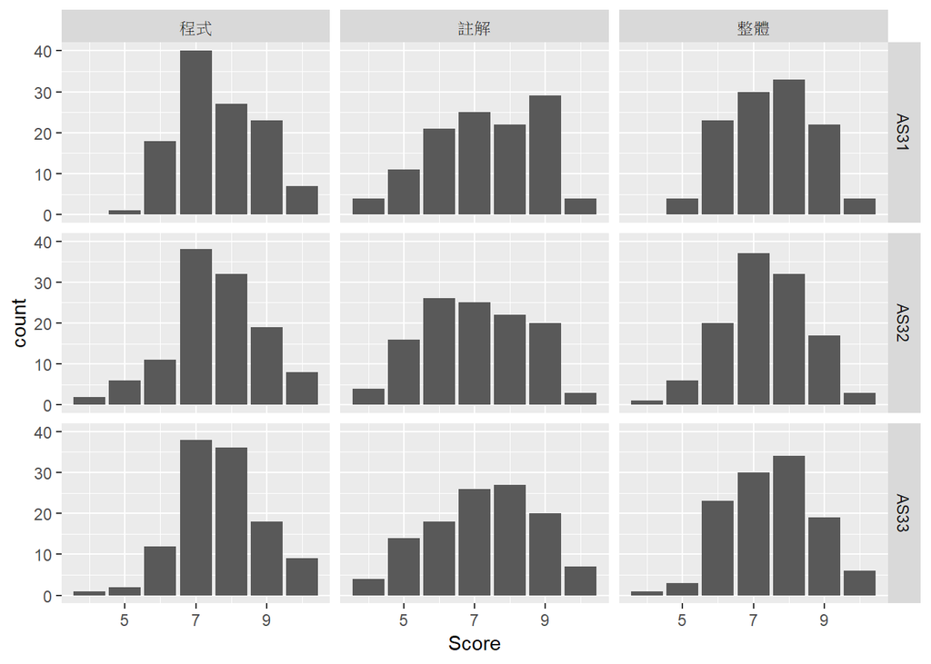

```r
ggplot(X2, aes(x=Score)) +
  geom_bar(position="dodge")+ facet_grid(AS ~ TYPE)
```

#### FIG2 - 評分的分布

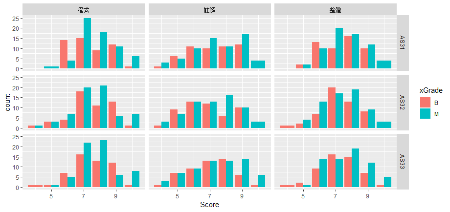

🗿: *如果我們要同時看大學生和研究生在每一份作業和每一個評分標準上面給分的分布(如FIG2)，我們應該要怎麼做呢？*

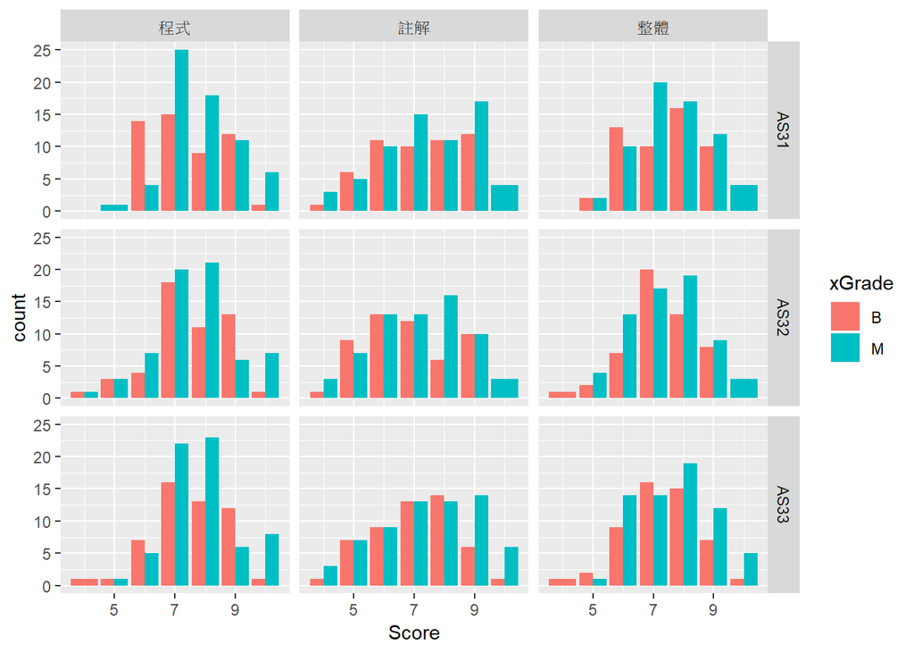

```r
ggplot(X2, aes(x=Score,fill=xGrade)) +
  geom_bar(position="dodge") + facet_grid(AS ~ TYPE)
```

#### 大學生與研究生的平均給分

```r
tapply(X2$Score, X2$xGrade, mean)
```

```
     B      M
7.2854 7.5333
```

#### 各組的平均給分

```r
rating = tapply(X2$Score, X2$xTeam, mean)
rating
```

```
  XT01   XT02   XT03   XT04   XT05   XT06   XT07   XT08   XT09   XT10   XT11
8.3889 7.6296 7.4889 6.7963 7.0926 7.9444 7.1778 6.9630 6.7963 7.4222 6.7593
  XT12   XT13   XT14   XT15   XT16   XT17   XT18   XT19   XT20   XT21
7.4667 7.8444 7.8889 7.2667 7.6944 7.4630 7.5926 7.7963 6.6222 7.8667
```

```r
range(rating)
```

```
[1] 6.6222 8.3889
```

#### 各組的平均得分

```r
rated = tapply(X2$Score, X2$rTeam, mean)
rated
```

```
  RT01   RT02   RT03   RT04   RT05   RT06   RT07   RT08   RT09   RT10   RT11
7.9111 6.7111 6.6667 8.1296 6.4667 7.0185 7.1333 7.8148 7.7333 7.6667 7.6889
  RT12   RT13   RT14   RT15   RT16   RT17   RT18   RT19   RT20   RT21
7.4074 6.9259 7.7778 6.9111 7.5185 8.5278 8.5370 6.2778 7.5556 7.5370
```

```r
range(rated)
```

```
[1] 6.2778 8.5370
```

🗿 問題討論：  
■ 由於我們的評分是自己小組的作業為基準，被評分數較高的小組會不會傾向於評出較低的分數呢？  
■ 請用統計的方法來檢定這一件事  
■ 請畫一個圖來檢驗這一件事  
■ 對資料科學家而言，上述哪一種方法比較有說服力呢？

```r
#統計方法會較有說服力
```

■ 對一般經理人員來說，上述哪一種方法比較有說服力呢？

```r
#用圖片會較有說服力
```

```r
#資料整理合併
rate=cbind(1:21,rated,rating)%>% data.frame %>% as.tbl %>% setNames(c("team","rated","rating"))
#給分>得分
rate$a= rate$rating/rate$rated>1
#給分與得分接近者
rate$b= rate$rating/rate$rated>0.95&rate$rating/rate$rated<1.05
```

```r
#相關係數檢定
cor.test(rate$rated,rate$rating)
```

```
    Pearson's product-moment correlation

data:  rate$rated and rate$rating
t = -0.552, df = 19, p-value = 0.59
alternative hypothesis: true correlation is not equal to 0
95 percent confidence interval:
 -0.52860  0.32366
sample estimates:
     cor
-0.12557
```

```r
#雖然相關係數小於0但p-value不低於0.05因此此次檢定不顯著
```

我們先把資料視覺化

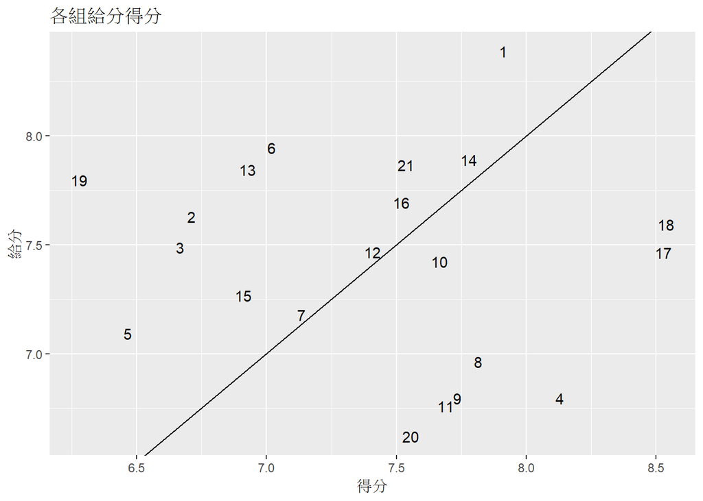

```r
ggplot(rate,aes(rated,rating,label=team))+
 geom_abline()+geom_text()+labs(title="各組給分得分",x="得分",y="給分")
```

從圖中可以發現有些點距離其他點很遠所以我們用另外一張圖來觀察

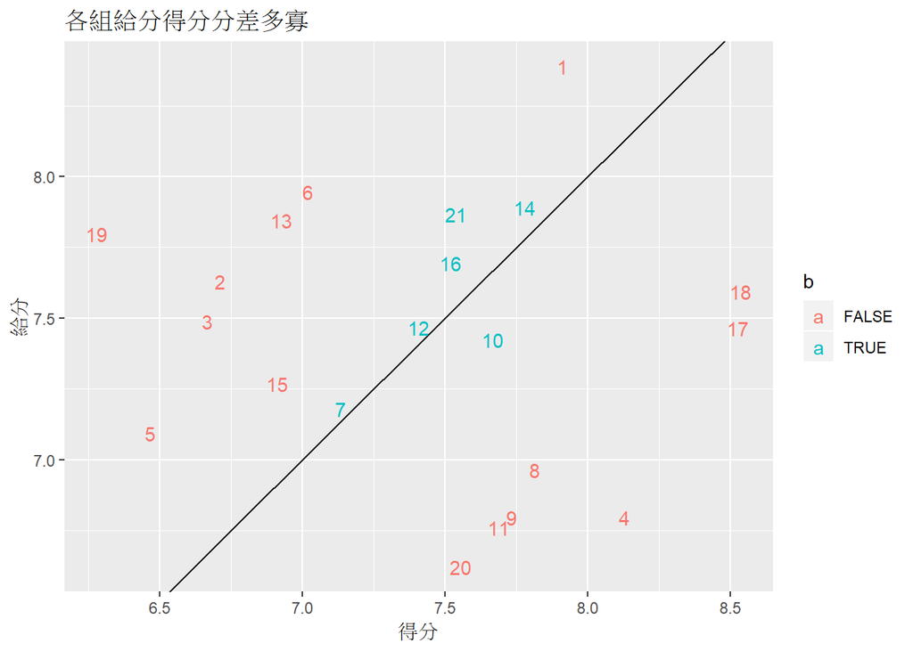

```r
ggplot(rate,aes(rated,rating,label=team,col=b))+
 geom_abline()+geom_text()+labs(title="各組給分得分分差多寡",x="得分",y="給分")
```

這張圖可以看到給分得分相當與差距較大的組別  
我們可以找到有部分點是遠離三大群的分別是1,5,17,18  
去除後可以得到下面這張圖

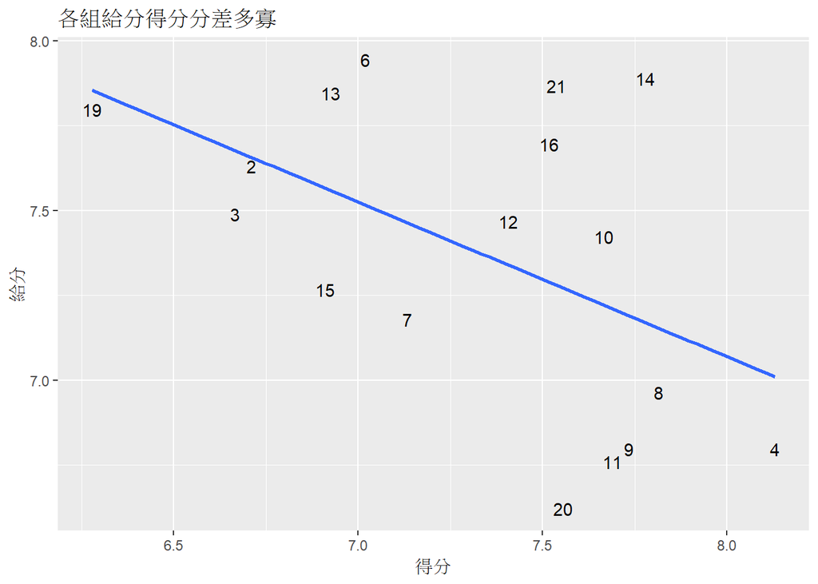

```r
ggplot(rate[-c(1,5,17,18),],aes(rated,rating,label=team))+
 geom_smooth(method="lm",se=F)+geom_text()+labs(title="各組給分得分分差多寡",x="得分",y="給分")
```

從圖上可以看出來各點分布的趨勢是往右下的從圖上判斷給分得分是負相關的 去除離群值後再做一次檢定

```r
ratefix=rate[-c(1,5,17,18),]
cor.test(ratefix$rated,ratefix$rating)
```

```
    Pearson's product-moment correlation

data:  ratefix$rated and ratefix$rating
t = -2.27, df = 15, p-value = 0.038
alternative hypothesis: true correlation is not equal to 0
95 percent confidence interval:
 -0.793719 -0.033746
sample estimates:
     cor
-0.50618
```

相關係數為-0.506且p-value小於0.05是顯著的因此我們可以判斷分數越高的組別給予的分數是相對較低的反之亦然